# Imputation/LCA FINAL

Michelle Le 30145965

2026-04-12

# Loading the Data

```r
# data <- read.csv(file.choose(), colClasses = "character") # run within R chunk
data <- read.csv("/Users/michellele/Downloads/data 501/5012-NGS-END_2020-CSV/ngs2020_pumf.csv", colClasses = "character") # run to knit as pdf

# check the number of rows
nrow(data)
```

```
## [1] 16138
```

```r
# filter the data to bachelors only
data <- data %>%
  filter(CERTLEVP == 2) # CERTLEVP refers to university certificate or diploma below a bachelor's degree AND bachelor's degree

# check the number of rows after filtering
nrow(data)
```

```
## [1] 6752
```

# Preliminary Data Cleaning

```r
# check how many columns are in the dataset before prelim cleaning
ncol_before <- ncol(data)
ncol_before
```

```
## [1] 116
```

```r
# we remove the following columns because they define employment outcomes and are not graduate characteristics
# although we do keep LFSTATP and LFCINDP for later***
# LFSTATP is employment status (employed, unemployed, etc.) -> this is what we are aiming to predict
# LFCINDP is job sector; required for job-sector specific analysis
oth_cols_to_remove <- c("CERTLEVP", # remove since we're only looking at bachelors; redundant column
                        "LMA_010",
                        "LMA2_07",
                        "LMA3_P01",
                        "LFCOCCP",
                        "LFWFTPTP",
                        "LMA6_05",
                        "LMA6_08",
                        "JOBQLEVP",
                        "JOBQLGRD",
                        "JOBQLINT",
                        "LMA6_11",
                        "LMA6_12",
                        "LMA6_13A",
                        "LMA6_13B",
                        "LMA6_13C",
                        "JOBINCP",
                        "LMA6_15",
                        "AFT_P010",
                        "AFT_P020",
                        "AFT_P040",
                        "AFT_050",
                        "AFT_070",
                        "AFT_080",
                        "AFT_090",
                        "WTPF", # remove the weights for now so they don't get accidentally imputed; although will need them later
                        "VERDATE",
                        "PERSINCP")

# remove the columns
data <- data[ , !(names(data) %in% oth_cols_to_remove)]

# check how many columns are left after prelim cleaning
ncol_after <- ncol(data)
ncol_after
```

```
## [1] 88
```

```r
# some columns use "99" to denote not-stated whereas other columns use "9"; we need to distinguish between these columns; we referenced the documentation provided by statscan (`NGS2020-PUMF_E.pdf`)

# these columns use "99"
cols_99 <- c("PGMCIPAP",
             "PGM_410",
             "PGM_415",
             "STL_030",
             "BEF_160",
             "LFCINDP"
             )
# length(cols_99)

# every other column uses "9"
cols_9 <- setdiff(names(data), c(cols_99, "PUMFID", "LFSTATP")) # every other column uses "9", do not include "PUMFID", "LFSTATP"
cols_9
```

```
##  [1] "REG_INST" "REG_RESP" "PGM_P034" "PGM_P036" "PGM_P100" "PGM_P111"
##  [7] "PGM_280A" "PGM_280B" "PGM_280C" "PGM_280D" "PGM_280E" "PGM_280F"
## [13] "PGM_290"  "PGM_350"  "PGM_380"  "PGM_P401" "PGM_430"  "COV_010"
## [19] "COV_070"  "COV_080"  "EDU_010"  "EDU_P020" "HLOSINTP" "STL_010"
## [25] "STL_020"  "STULOANS" "OWESLGD"  "OWEGVIN"  "STL_080"  "STL_100A"
## [31] "STL_100B" "STL_100C" "STL_100D" "STL_130"  "STL_150"  "STL_160B"
## [37] "STL_160C" "STL_160D" "STL_160E" "STL_160F" "STL_160G" "STL_160H"
## [43] "STL_160I" "STL_160J" "STL_160L" "STLP160N" "SRCFUND"  "STL_170A"
## [49] "STL_170B" "STL_170C" "STL_170D" "STL_170E" "STL_170F" "STL_170G"
## [55] "STL_170H" "STL_170I" "STL_170J" "STL_170L" "STLP170N" "RESPP"
## [61] "STL_190"  "DBTOTGRD" "DBTALGRD" "DBTOTINT" "DBTALINT" "SCHOLARP"
## [67] "BEF_P140" "PREVLEVP" "HLOSGRDP" "PAR1GRD"  "PAR1INT"  "PAR2GRD"
## [73] "PAR2INT"  "GRADAGEP" "GENDER2"  "MS_P01"   "MS_P02"   "CTZSHIPP"
## [79] "VISBMINP" "DDIS_FL"
```

```r
# length(cols_9)

# replace "not-stated" (denoted by either "99" or "9") with NA
data <- data %>%
  mutate(
    across(all_of(cols_99), ~na_if(., "99")),
    across(all_of(cols_9),  ~na_if(., "9"))
  )
```

Moving forward, we will only be working with data applicable to all respondents. Whether a question was applicable to all respondents is defined by the universe. The universe for each question can be found in the `NGS2020-PUMF_E.pdf` document. The following variables were applicable to all respondents:

```r
# define which columns are applicable to all respondents
allresp_universe <- c("REG_INST", # region of inst
                      "REG_RESP", # region of res 2023
                      "PGMCIPAP", # 2020 program
                      "PGM_P034", # 2020 full-time vs part-time
                      "PGM_P100", # work placement during program status
                      "PGM_280A", # started a business
                      "PGM_280B", # completed entrepreneurship courses
                      "PGM_280C", # business plan or pitch comp
                      "PGM_280D", # visited entrepreneurship centre
                      "PGM_280E", # worked on entrepreneurship project
                      "PGM_280F", # entrepreneurship - none of the above
                      "PGM_290", # worked during the program
                      "PGM_350", # volunteered during the program
                      "PGM_380", # completed components taken outside of canada
                      "PGM_P401", # online/distance education prior to COVID-19
                      "PGM_410", # main factor in choice of inst
                      "PGM_415", # main factor in choice of program
                      "PGM_430", # choose to repeat field of study
                      "EDU_010", # other programs taken since 2020
                      "HLOSINTP", # 2023 highest level of educ comp
                      "STL_010", # applied for student loan
                      "STULOANS", # received student loan
                      "STL_160B", # RESP for funding
                      "STL_160C", # grant/bursary for funding
                      "STL_160D", # non-gov grant/bursary for funding
                      "STL_160E", # scholarship/award for funding
                      "STL_160F", # employment earnings/savings for fund
                      "STL_160G", # research/TA for funding
                      "STL_160H", # parents, family, friends for funding
                      "STL_160I", # bank loan for funding
                      "STL_160J", # credit card for funding
                      "STL_160L", # employer for funding
                      "STLP160N", # other for funding
                      # "DBTALGRD", # debt; universe != all respondents
                      "BEF_P140", # main activity before 2020 program
                      "BEF_160", # work exp before 2020 program
                      "HLOSGRDP", # 2020 highest level of educ comp
                      "PAR1GRD", # parent 1 education 2020
                      "PAR1INT", # parent 1 education 2023
                      "PAR2GRD", # parent 2 education 2020
                      "PAR2INT", # parent 2 education 2023
                      "GRADAGEP", # 2020 age
                      "GENDER2", # gender
                      "MS_P01", # curr marital status
                      "MS_P02", # dependent children status
                      "CTZSHIPP", # 2023 citizenship status
                      "VISBMINP", # visible minority membership
                      "DDIS_FL" # disability status
                      )

# drop columns not applicable to all respondents
data_reduced <- data[ , (names(data) %in% allresp_universe)]
data_reduced$LFSTATP <- data$LFSTATP # add back LFSTATP
data_reduced$PUMFID <- data$PUMFID # add back PUMFID
data_reduced$LFCINDP <- data$LFCINDP # add back LFCINDP
```

# Check Missing Data

```r
# To evaluate missingness patterns, ChatGPT was consulted to find the best way to observe them visually. Analysis of missingness patterns was done by me.
# OpenAI. (2026). ChatGPT [Large language model]. https://chat.openai.com
```

```r
# check whether the response has any missing data
sum(is.na(data_reduced$LFSTATP))
```

```
## [1] 0
```

```r
# check whether the ID column has any missing data
sum(is.na(data_reduced$PUMFID))
```

```
## [1] 0
```

```r
# check whether the LFCINDP column has any missing data
sum(is.na(data_reduced$LFCINDP))
```

```
## [1] 154
```

```r
# check the number of non-responses per column
survey_cols <- intersect(c(cols_99, cols_9), names(data_reduced))
col_missing <- colSums(is.na(data_reduced[, survey_cols]))
sort(col_missing, decreasing = TRUE)
```

```
##  PAR2GRD  PAR2INT CTZSHIPP  PAR1GRD  PAR1INT  BEF_160 VISBMINP   MS_P02
##      493      457      413      341      307      217      173      160
## HLOSGRDP  LFCINDP BEF_P140   MS_P01 STL_160B STL_160C STL_160D STL_160E
##      158      154      153      153      144      144      144      144
## STL_160F STL_160G STL_160H STL_160I STL_160J STL_160L STLP160N REG_RESP
##      144      144      144      144      144      144      144       81
## PGM_280A PGM_280B PGM_280C PGM_280D PGM_280E PGM_280F GRADAGEP  PGM_415
##       44       44       44       44       44       44       29       21
## PGMCIPAP PGM_P034 PGM_P100  EDU_010 STULOANS  PGM_410  PGM_430  STL_010
##       18       14       12        9        9        7        7        6
##  PGM_350  PGM_380 PGM_P401  PGM_290 REG_INST HLOSINTP  GENDER2  DDIS_FL
##        5        5        4        2        0        0        0        0
```

```r
# get the top 5 missing columns
top_missing_cols <- names(sort(col_missing, decreasing = TRUE)[1:5])

# check which column has the most non-responses
which.max(colSums(is.na(data_reduced[, survey_cols]))) # output is the column name and the corresponding index
```

```
## PAR2GRD
##      40
```

```r
# check the non-response rate per column
missing_prop <- colMeans(is.na(data_reduced[, survey_cols]))
round(missing_prop*100, 2) # multiply by 100 to get a percentage -> this is easier to read
```

```
## PGMCIPAP  PGM_410  PGM_415  BEF_160  LFCINDP REG_INST REG_RESP PGM_P034
##     0.27     0.10     0.31     3.21     2.28     0.00     1.20     0.21
## PGM_P100 PGM_280A PGM_280B PGM_280C PGM_280D PGM_280E PGM_280F  PGM_290
##     0.18     0.65     0.65     0.65     0.65     0.65     0.65     0.03
##  PGM_350  PGM_380 PGM_P401  PGM_430  EDU_010 HLOSINTP  STL_010 STULOANS
##     0.07     0.07     0.06     0.10     0.13     0.00     0.09     0.13
## STL_160B STL_160C STL_160D STL_160E STL_160F STL_160G STL_160H STL_160I
##     2.13     2.13     2.13     2.13     2.13     2.13     2.13     2.13
## STL_160J STL_160L STLP160N BEF_P140 HLOSGRDP  PAR1GRD  PAR1INT  PAR2GRD
##     2.13     2.13     2.13     2.27     2.34     5.05     4.55     7.30
##  PAR2INT GRADAGEP  GENDER2   MS_P01   MS_P02 CTZSHIPP VISBMINP  DDIS_FL
##     6.77     0.43     0.00     2.27     2.37     6.12     2.56     0.00
```

```r
# check the number of non-responses per respondent
row_missing <- rowSums(is.na(data_reduced[, survey_cols]))
# row_missing

# check the proportion of non-responses per respondent
row_missing_prop <- row_missing / length(survey_cols)
# row_missing_prop

respondent_nonresp <- data.frame(row_missing, row_missing_prop)
# get summary statistics for the number of non-responses per respondent
summary(row_missing)
```

```
##    Min. 1st Qu.  Median    Mean 3rd Qu.    Max.
##  0.0000  0.0000  0.0000  0.7784  0.0000 26.0000
```

```r
# get the summary statistics for the proportion of non-response per respondent
summary(row_missing_prop)
```

```
##    Min. 1st Qu.  Median    Mean 3rd Qu.    Max.
## 0.00000 0.00000 0.00000 0.01622 0.00000 0.54167
```

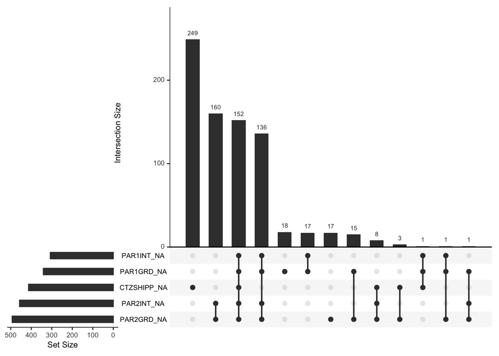

```r
# plot a visual summary
# observe which combinations of NAs frequently occur
gg_miss_upset(data_reduced[, survey_cols])
```

The above visualization summarizes the most common combinations of survey questions left unanswered. Notably, parent’s education level (`PAR2GRD`, `PAR2INT`, `PAR1GRD`, `PAR1INT`) and citizenship status (`CTZSHIPP`) were most commonly unanswered.

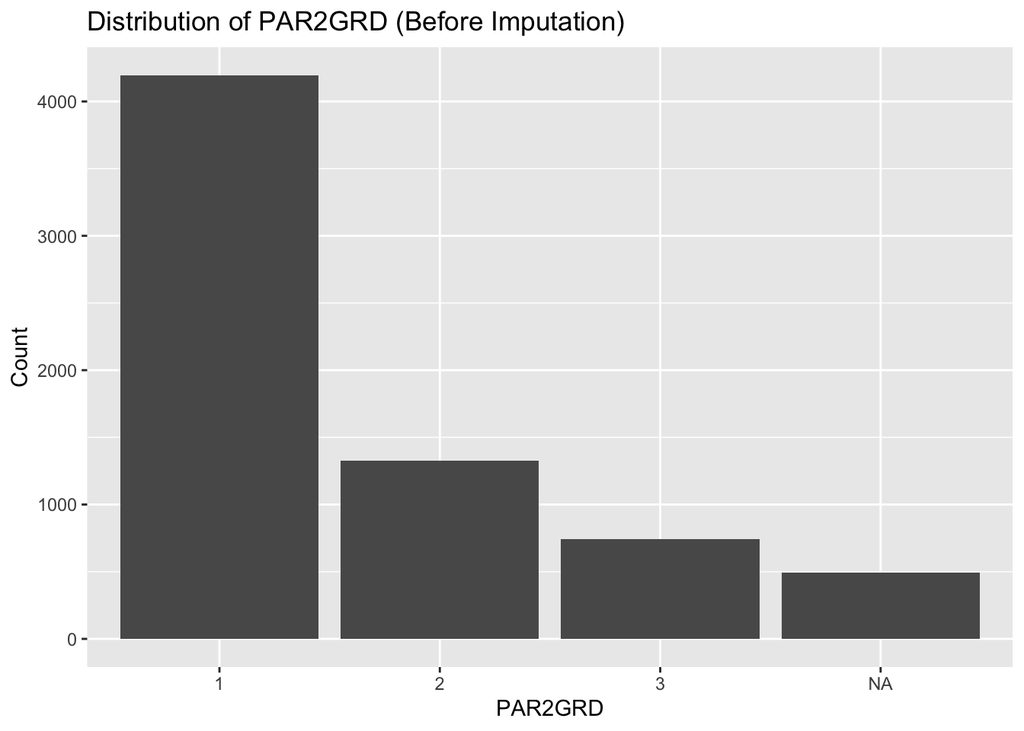

```r
# check the distribution of the missing data before imputation
p1 <- ggplot(data_reduced, aes(x = PAR2GRD)) +
  geom_bar() +
  labs(title = "Distribution of PAR2GRD (Before Imputation)",
       x = "PAR2GRD",
       y = "Count")

p2 <- ggplot(data_reduced, aes(x = PAR2INT)) +
  geom_bar() +
  labs(title = "Distribution of PAR2INT (Before Imputation)",
       x = "PAR2INT",
       y = "Count")

p3 <- ggplot(data_reduced, aes(x = CTZSHIPP)) +
  geom_bar() +
  labs(title = "Distribution of CTZSHIPP (Before Imputation)",
       x = "CTZSHIPP",
       y = "Count")

p4 <- ggplot(data_reduced, aes(x = PAR1GRD)) +
  geom_bar() +
  labs(title = "Distribution of PAR1GRD (Before Imputation)",
       x = "PAR1GRD",
       y = "Count")

p5 <- ggplot(data_reduced, aes(x = PAR1INT)) +
  geom_bar() +
  labs(title = "Distribution of PAR1INT (Before Imputation)",
       x = "PAR1INT",
       y = "Count")

p1
```

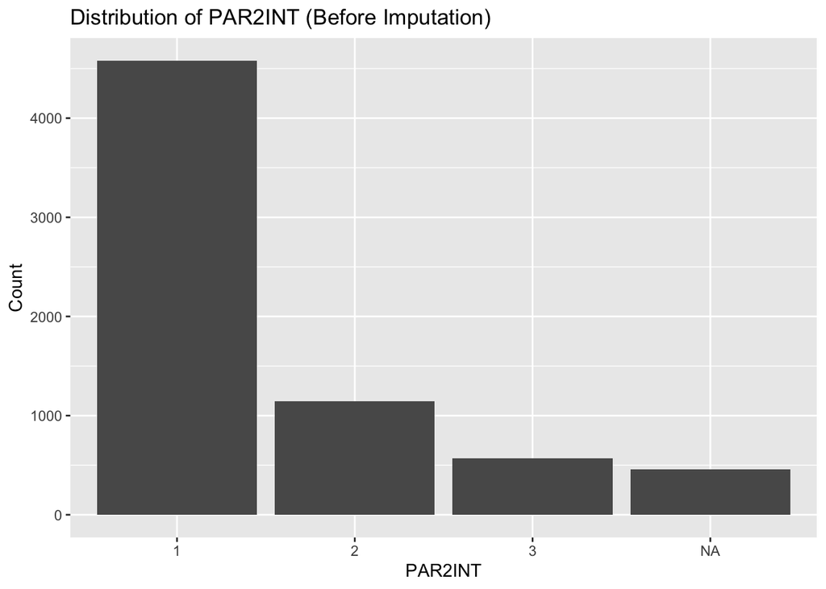

```r
p2
```

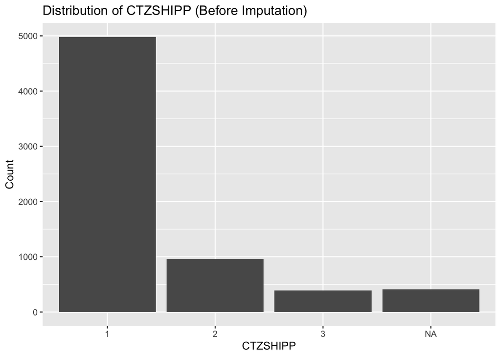

```r
p3
```

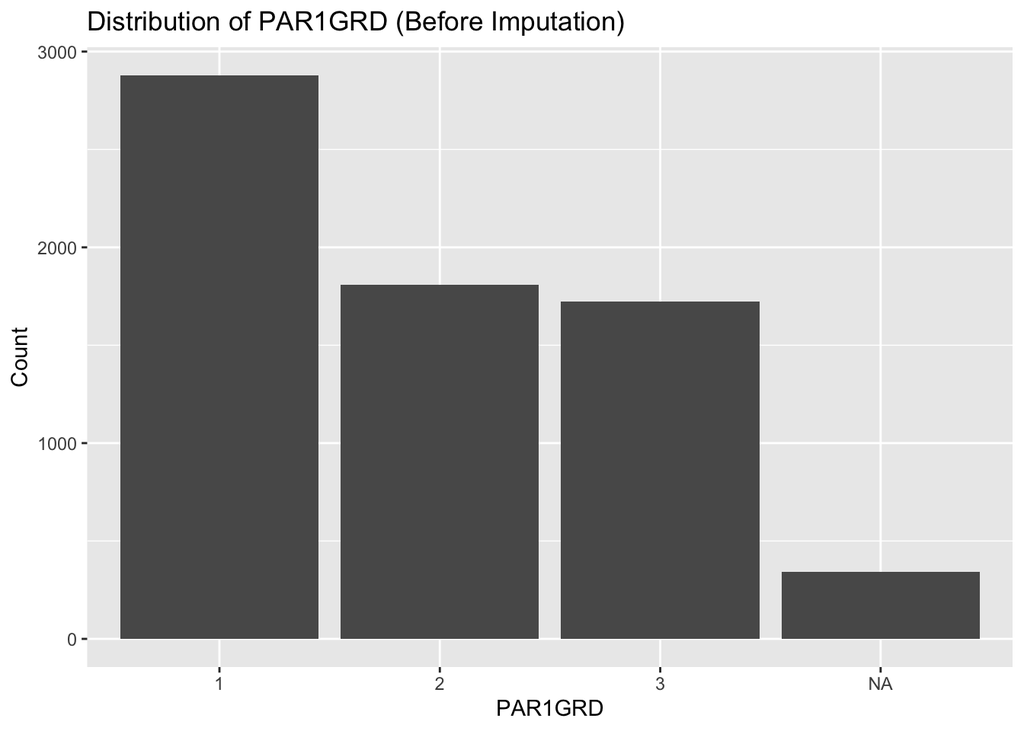

```r
p4
```

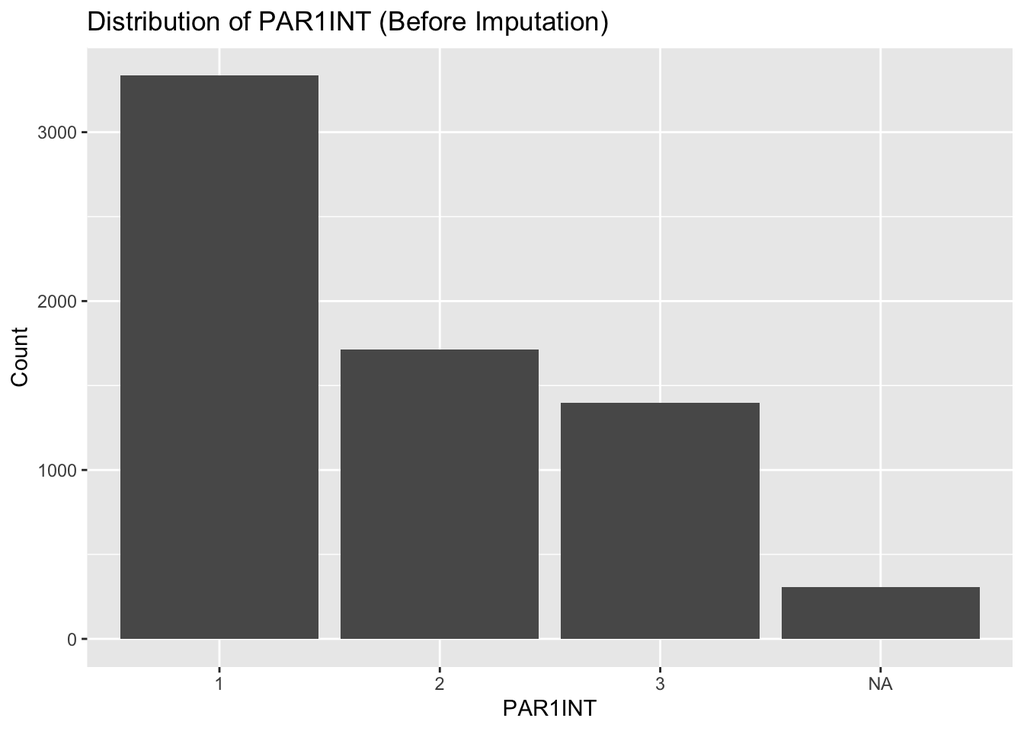

```r
p5
```

# Imputation

```r
# The idea of using MICE came from ChatGPT.
# OpenAI. (2026). ChatGPT [Large language model]. https://chat.openai.com

# Implementation of MICE came from the following
# GeeksforGeeks. (2025, July 23). Mice package in R. https://www.geeksforgeeks.org/r-language/mice-package-in-r/
```

We will use Multiple Imputation with Chained Equations (MICE) to handle the missing data. The following code includes the code for MICE, however, it has been commented out to improve computational efficiency upon running this script.

```r
# exclude PUMFID and LFSTATP since they are not missing
data_impute <- data_reduced %>%
  dplyr::select(-PUMFID)
data_impute <- data_impute %>%
  dplyr::select(-LFSTATP)

names(data_impute)
```

```
##  [1] "REG_INST" "REG_RESP" "PGMCIPAP" "PGM_P034" "PGM_P100" "PGM_280A"
##  [7] "PGM_280B" "PGM_280C" "PGM_280D" "PGM_280E" "PGM_280F" "PGM_290"
## [13] "PGM_350"  "PGM_380"  "PGM_P401" "PGM_410"  "PGM_415"  "PGM_430"
## [19] "EDU_010"  "HLOSINTP" "STL_010"  "STULOANS" "STL_160B" "STL_160C"
## [25] "STL_160D" "STL_160E" "STL_160F" "STL_160G" "STL_160H" "STL_160I"
## [31] "STL_160J" "STL_160L" "STLP160N" "BEF_P140" "BEF_160"  "HLOSGRDP"
## [37] "PAR1GRD"  "PAR1INT"  "PAR2GRD"  "PAR2INT"  "GRADAGEP" "GENDER2"
## [43] "MS_P01"   "MS_P02"   "CTZSHIPP" "VISBMINP" "DDIS_FL"  "LFCINDP"
```

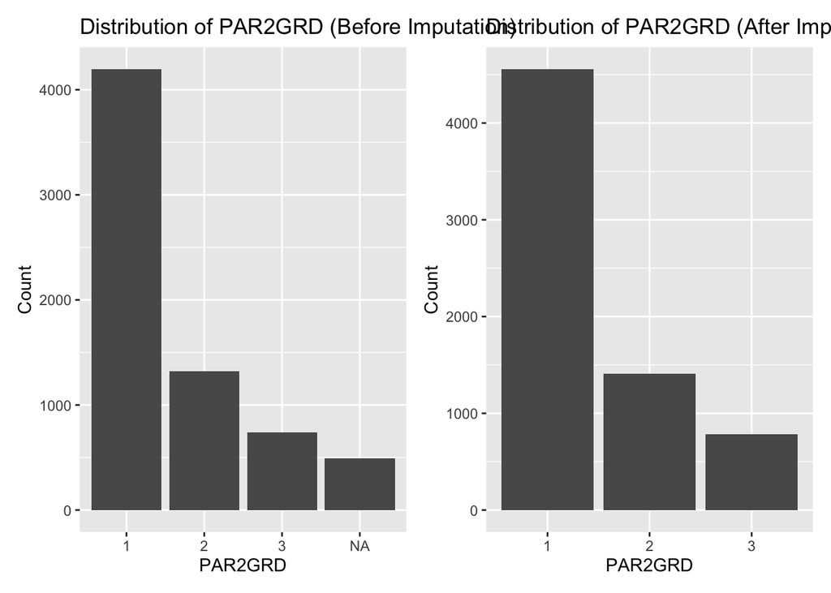

```r
# convert to factor
data_impute <- data_impute %>%
  mutate(across(everything(), as.factor))

# imp <- mice(data_impute,
#             m = 5, # create 5 datasets
#             maxit = 20, # run 20 iterations for stability
#             method = "cart", # use cart
#             seed = 123) # use seed for reproducability
#
# # diagnostic plots to ensure good mixing
# # plot(imp)
# # stripplot(imp, pch = 20, cex = 1.2)
# # summary(imp)
#
# # for now, we'll take the first complete dataset out of the 5 generated and use this for our lca
# data_completed <- complete(imp, 1)

# # write each of the five datasets to a csv so we don't have to run mice again (computationally exhaustive)
# # for later analysis, we will need to pool the 5 datasets
# for (i in 1:5) {
#   # get the ith completed dataset
#   completed_data <- complete(imp, i)
#
#   # create a file name
#   file_name <- paste0("data_completed_imp", i, ".csv")
#
#   # write to CSV
#   write.csv(completed_data, file_name, row.names = FALSE)
# }

# completed datasets are also provided
data_completed <- read.csv('/Users/michellele/Downloads/data 501/data_completed_imp1.csv', colClasses = "character")

# add back the ID and employment status columns
data_completed$PUMFID <- data_reduced$PUMFID
data_completed$LFSTATP <- data_reduced$LFSTATP

# check the distributions after imputation
p6 <- ggplot(data_completed, aes(x = PAR2GRD)) +
  geom_bar() +
  labs(title = "Distribution of PAR2GRD (After Imputation)",
       x = "PAR2GRD",
       y = "Count")

p7 <- ggplot(data_completed, aes(x = PAR2INT)) +
  geom_bar() +
  labs(title = "Distribution of PAR2INT (After Imputation)",
       x = "PAR2INT",
       y = "Count")

p8 <- ggplot(data_completed, aes(x = CTZSHIPP)) +
  geom_bar() +
  labs(title = "Distribution of CTZSHIPP (After Imputation)",
       x = "CTZSHIPP",
       y = "Count")

p9 <- ggplot(data_completed, aes(x = PAR1GRD)) +
  geom_bar() +
  labs(title = "Distribution of PAR1GRD (After Imputation)",
       x = "PAR1GRD",
       y = "Count")

p10 <- ggplot(data_completed, aes(x = PAR1INT)) +
  geom_bar() +
  labs(title = "Distribution of PAR1INT (After Imputation)",
       x = "PAR1INT",
       y = "Count")

p1 + p6
```

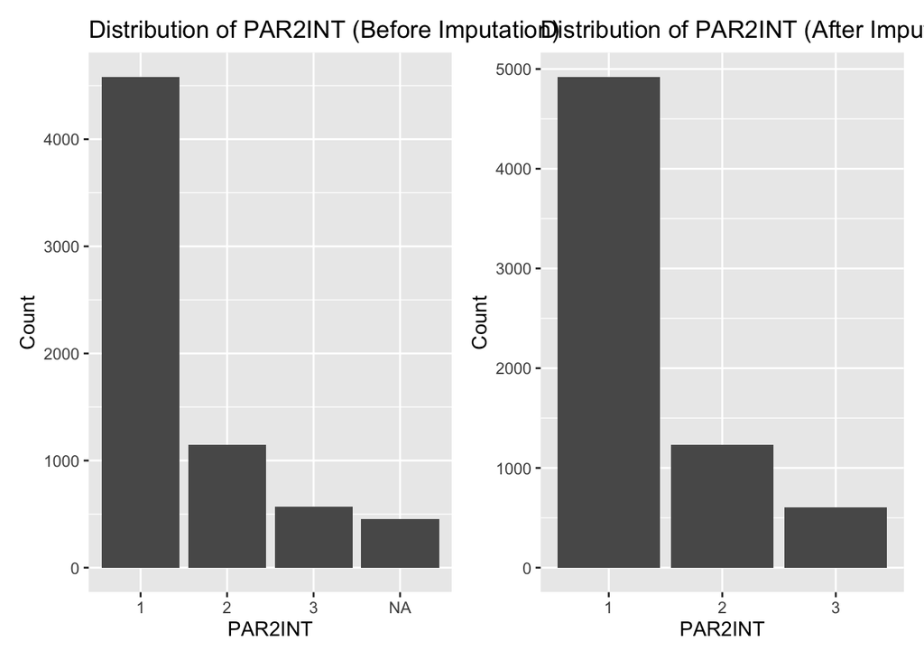

```r
p2 + p7
```

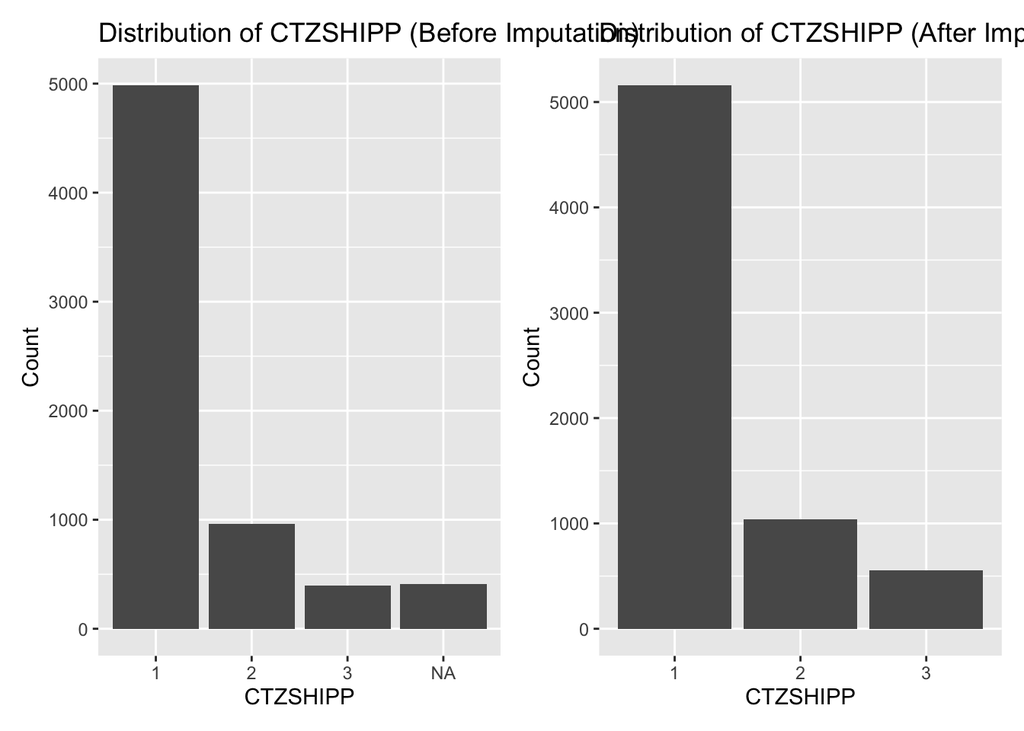

```r
p3 + p8
```

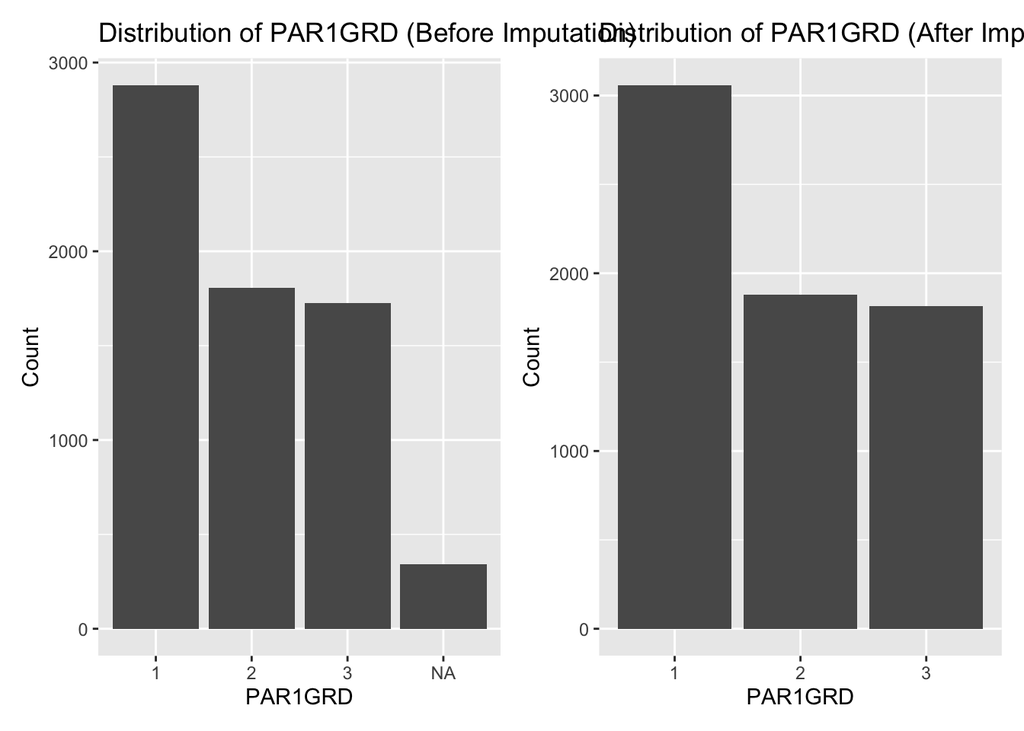

```r
p4 + p9
```

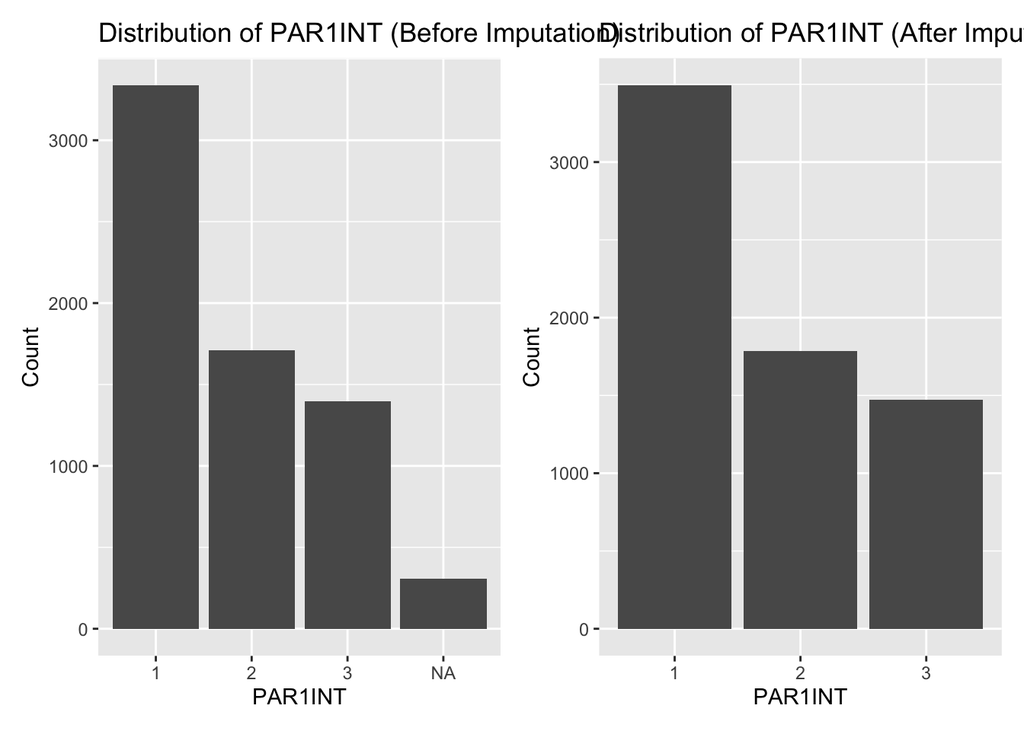

```r
p5 + p10
```

From these plots, we can observe that the distribution before and after MICE is relatively similar.

# LCA Indicator Selection

```r
# LCA indicator selection was inspired from the following
# Sinha, P., Calfee, C. S., & Delucchi, K. L. (2021). Practitioner’s guide to latent class analysis: Methodological considerations and common pitfalls. Critical Care Medicine, 49(1), e63–e79. https://doi.org/10.1097/CCM.0000000000004710

# Implementation of LCA came from the following
# GeeksforGeeks. (2025, July 23). Latent class analysis in R. https://www.geeksforgeeks.org/r-machine-learning/latent-class-analysis-in-r/
```

With LCA, it is not the case that more indicators is better. Too many indicators will increase model complexity, reduce interpretability and cause convergence problems. Moreover, good LCA models should produce clear separation between classes. Thus, indicators that are composite of other indicators should be excluded.

Therefore, to guide our feature selection, we need to consider which variables fit within our conceptual framework, exclude variables that break LCA assumptions such as conditional independence, and exclude low-information variables (i.e., small variance).

While factors such as the region of the respondent’s institution and resident may provide some useful insights, we are not particularly interested in these indicators. Similarly, we are not interested in the respondent’s main factor in their choice of institution and/or program or whether they would choose the same program again if they could. That is, regional and institutional variables are not part of our conceptual framework.

To some extent, we are interested in the respondent’s entrepreneurship skills. Particularly, whether or not they were trained in or had exposure to them, not how. For this reason, we will collapse the entrepreneurship skills section into one variable.

```r
data_completed$entrepreneurship_any <- ifelse(
  data_completed$PGM_280A == 1 |
  data_completed$PGM_280B == 1 |
  data_completed$PGM_280C == 1 |
  data_completed$PGM_280D == 1 |
  data_completed$PGM_280E == 1,
  1, 2
)
```

Similarly, we are somewhat interested in how the respondent financed their education (specifically, whether or not they received student loans).

Based on this criteria we will tentatively explore:

- `PGMCIPAP`
- `PGM_P034`
- `PGM_P100`
- `entrepreneurship_any`
- `PGM_290`
- `PGM_350`
- `PGM_380`
- `PGM_P401`
- `EDU_010`
- `HLOSINTP`
- `STULOANS`
- `BEF_P140`
- `BEF_160`
- `PAR1GRD`
- `PAR1INT`
- `PAR2GRD`
- `PAR2INT`
- `GRADAGEP`
- `GENDER2`
- `CTZSHIPP`
- `VISBMINP`
- `DDIS_FL`

We can also narrow these down further by evaluating their variances. We will not move forward with any variables that present limited variance.

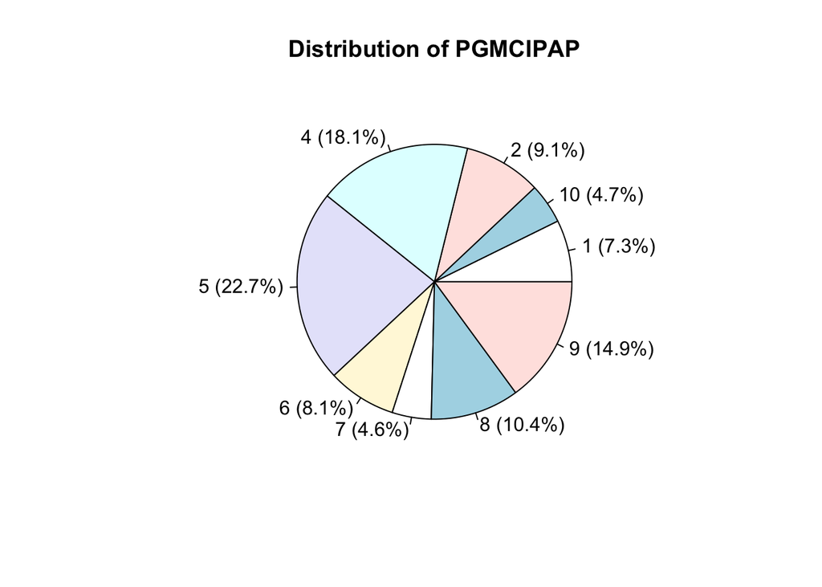

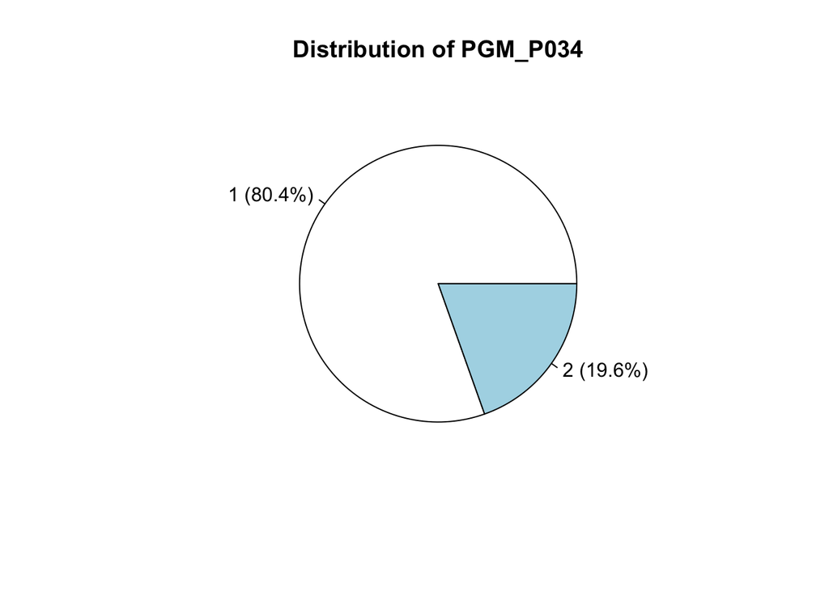

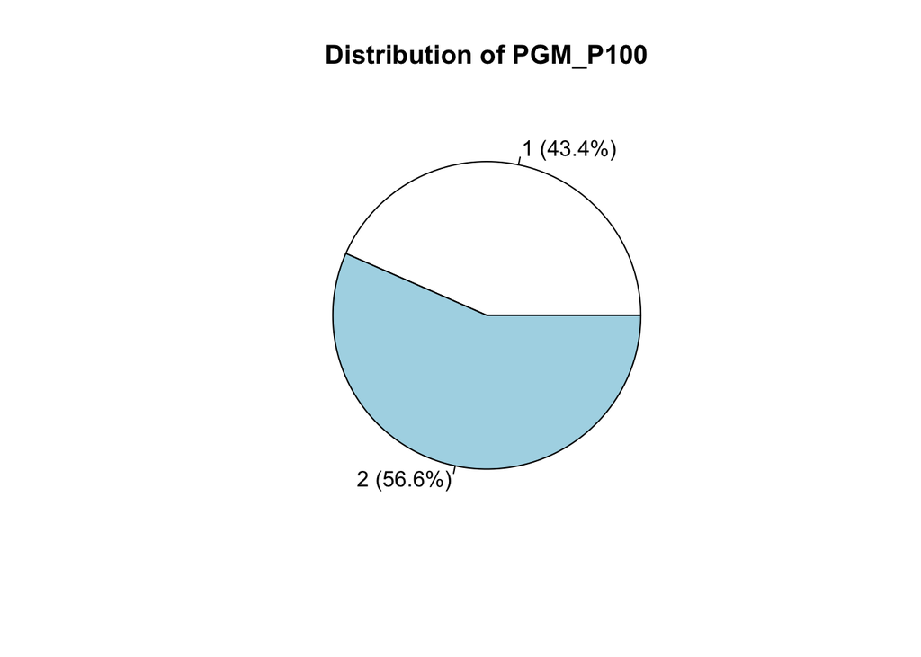

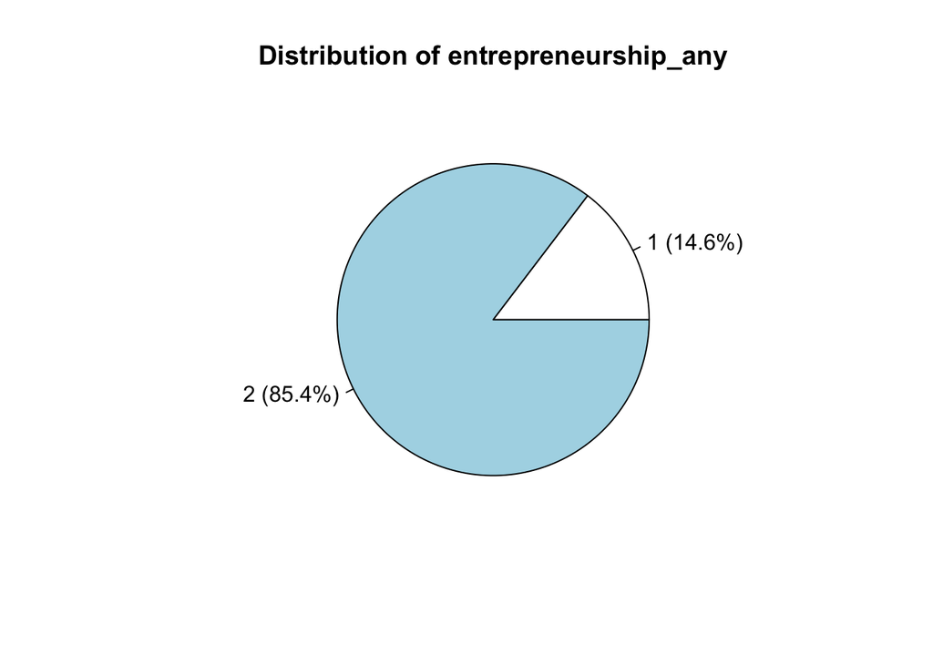

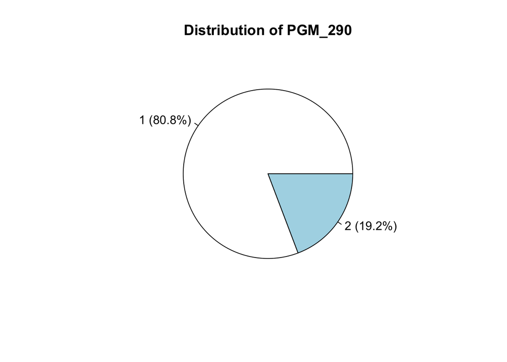

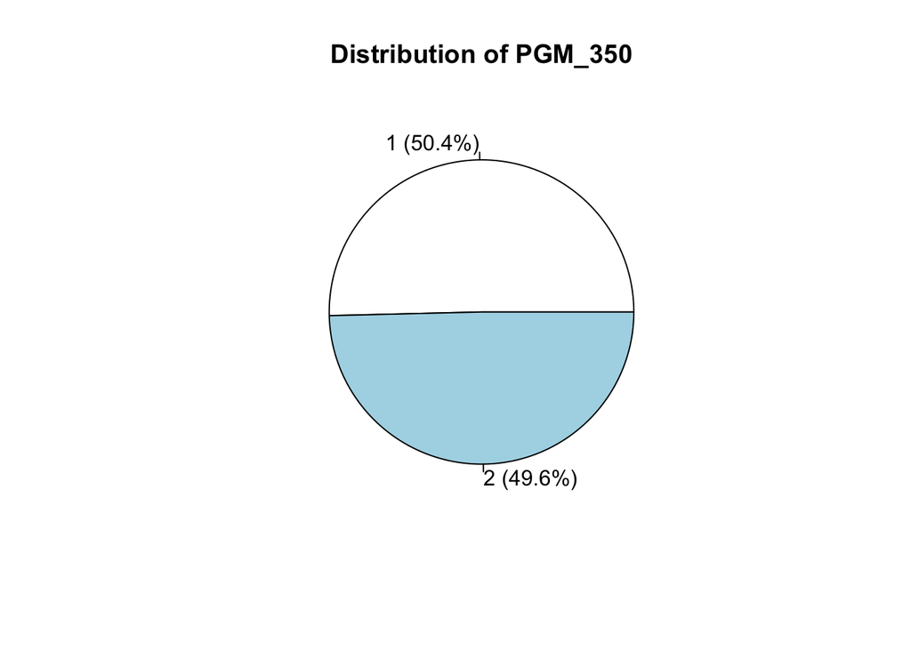

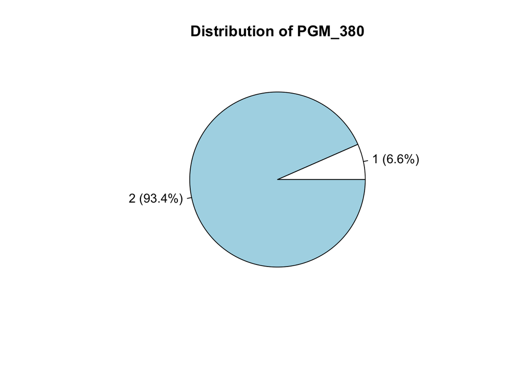

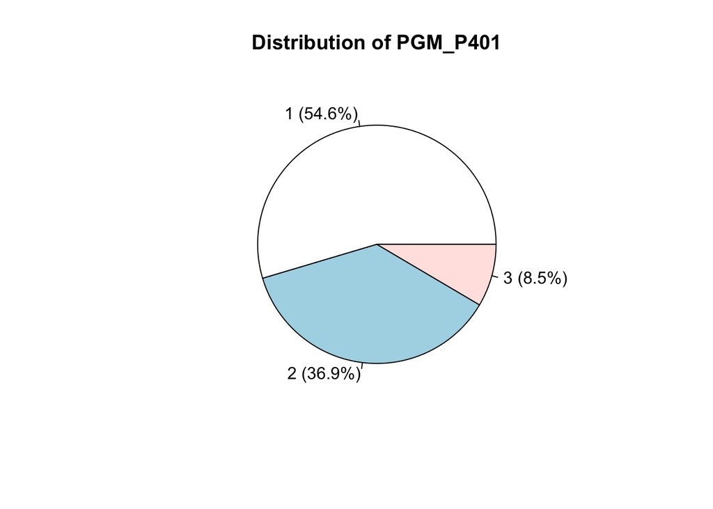

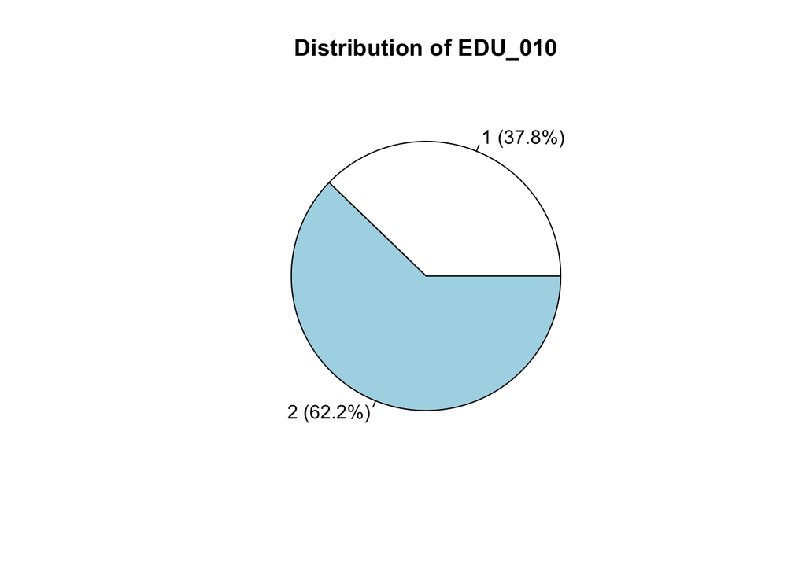

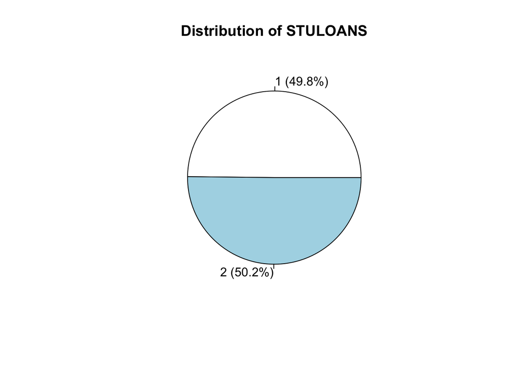

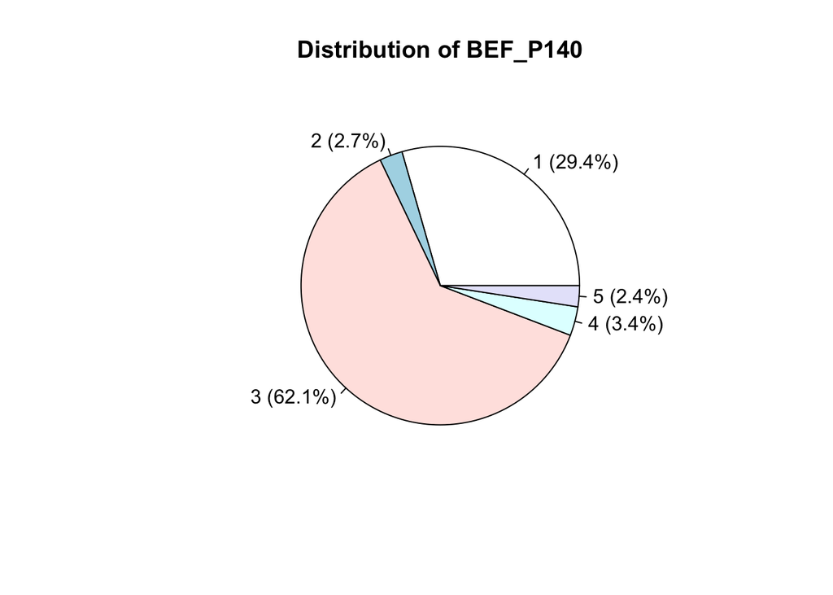

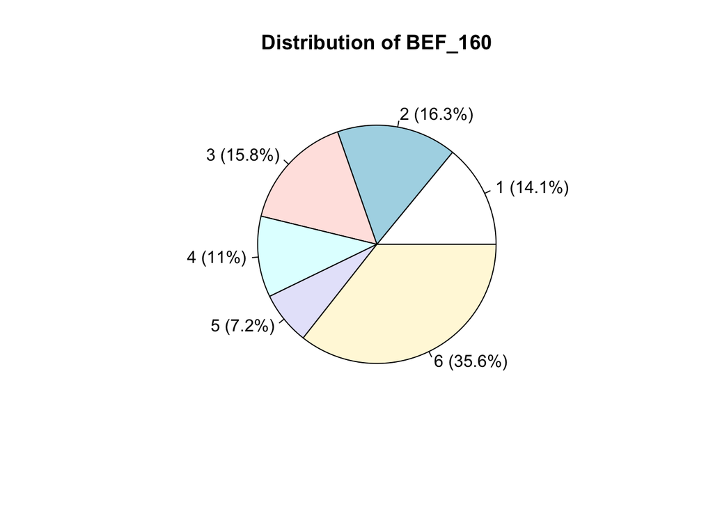

[9 more figures not shown]

```r
potential_lca_vars <- c(
  "PGMCIPAP", # 2020 Program - Aggregated CIP 2021
  "PGM_P034", # 2020 Program - Full-time or part-time student
  "PGM_P100", # Work placement during program
  "entrepreneurship_any",
  "PGM_290", # 2020 Program - Worked during program
  "PGM_350", # 2020 Program - Volunteer activities during program
  "PGM_380", # 2020 Program - Components taken outside of Canada
  "PGM_P401", # 2020 Program - Online or distance education
  "EDU_010", # After 2020 program - Other postsecondary programs taken
  "STULOANS", # Government-student loan program - Received
  "BEF_P140", # Before 2020 Program - Main activity during 12 months before
  "BEF_160", # Before 2020 program - Number of months of work experience
  "PAR1GRD", # 2020 Program - Level of education vs of the other parent
  "PAR1INT", # 2023 Program - Level of education vs of the other parent
  "PAR2GRD", # 2020 Program - Level of education vs of the other parent
  "PAR2INT", # 2023 Program - Level of education vs of the other parent
  "GRADAGEP", # 2020 Program - Age at time of graduation - Grouping
  "GENDER2", # Gender after distribution of non-binary persons
  "CTZSHIPP", # Time of interview 2023 - Status in Canada
  "VISBMINP", # Self-identified as a member of a visible minority group
  "DDIS_FL" # Disability status
)

for(v in potential_lca_vars){

  tab <- table(data_completed[[v]])

  pie(tab,
      main = paste("Distribution of", v),
      labels = paste0(names(tab), " (", round(prop.table(tab)*100,1), "%)"))
}
```

```r
# compute the largest proportions for each column
max_prop <- sapply(data_completed[potential_lca_vars], function(x) {
  max(prop.table(table(x)))
})

# remove them from the lca analysis
lca_vars <- potential_lca_vars[max_prop <= 0.95]

removed_vars <- potential_lca_vars[max_prop > 0.95]
removed_vars
```

```
## character(0)
```

```r
# is there really a difference between `PAR1GRD` and `PAR1INT`/`PAR2GRD` and `PAR2INT`?
# we consider dropping the latter from our analysis as they may be composite features
lca_vars <- lca_vars[!lca_vars %in% c("PAR1INT", "PAR2INT")]

# check how many indicators there are
length(lca_vars)
```

```
## [1] 19
```

# LCA

```r
# The logic for computing the entropy and pseudo likelihood test were derived from ChatGPT.
# OpenAI. (2026). ChatGPT [Large language model]. https://chat.openai.com
```

```r
# subset the data; only include variables we want to include in the LCA as defined previously
lca_data <- data_completed %>%
  dplyr::select("PUMFID", "LFSTATP", dplyr::all_of(lca_vars))

# convert LCA indicators to factors if not already
lca_data[lca_vars] <- lapply(lca_data[lca_vars], as.factor)

# define the formula
f <- as.formula(
  paste("cbind(", paste(lca_vars, collapse = ", "), ") ~ 1")
)

# run with 2-8 classes
lca_2 <- poLCA(f, lca_data, nclass = 2, maxiter = 5000, nrep = 10)
```

```
## Model 1: llik = -102258.9 ... best llik = -102258.9
## Model 2: llik = -102258.9 ... best llik = -102258.9
## Model 3: llik = -102258.9 ... best llik = -102258.9
## Model 4: llik = -102258.9 ... best llik = -102258.9
## Model 5: llik = -102258.9 ... best llik = -102258.9
## Model 6: llik = -102258.9 ... best llik = -102258.9
## Model 7: llik = -102258.9 ... best llik = -102258.9
## Model 8: llik = -102258.9 ... best llik = -102258.9
## Model 9: llik = -102258.9 ... best llik = -102258.9
## Model 10: llik = -102258.9 ... best llik = -102258.9
## Conditional item response (column) probabilities,
##  by outcome variable, for each class (row)
##
## $PGMCIPAP
##                1     10      2      4      5      6      7      8      9
## class 1:  0.0502 0.0423 0.0964 0.1905 0.2006 0.1067 0.0519 0.1294 0.1321
## class 2:  0.1228 0.0582 0.0798 0.1610 0.2849 0.0235 0.0333 0.0489 0.1876
##
## $PGM_P034
##                1      2
## class 1:  0.9065 0.0935
## class 2:  0.5790 0.4210
##
## $PGM_P100
##                1      2
## class 1:  0.4319 0.5681
## class 2:  0.4388 0.5612
##
## $entrepreneurship_any
##                1      2
## class 1:  0.1600 0.8400
## class 2:  0.1166 0.8834
##
## $PGM_290
##                1      2
## class 1:  0.8147 0.1853
## class 2:  0.7925 0.2075
##
## $PGM_350
##                1      2
```

[output cut: 72 more lines]

```
##  0.6945 0.3055
##
## =========================================================
## Fit for 2 latent classes:
## =========================================================
## number of observations: 6752
## number of estimated parameters: 79
## residual degrees of freedom: 6673
## maximum log-likelihood: -102258.9
##
## AIC(2): 204675.7
## BIC(2): 205214.3
## G^2(2): 85927.12 (Likelihood ratio/deviance statistic)
## X^2(2): 1118973520 (Chi-square goodness of fit)
##
```

```r
lca_3 <- poLCA(f, lca_data, nclass = 3, maxiter = 5000, nrep = 10)
```

```
## Model 1: llik = -100372.4 ... best llik = -100372.4
## Model 2: llik = -100372.4 ... best llik = -100372.4
## Model 3: llik = -100372.4 ... best llik = -100372.4
## Model 4: llik = -100372.4 ... best llik = -100372.4
## Model 5: llik = -100372.4 ... best llik = -100372.4
## Model 6: llik = -100372.4 ... best llik = -100372.4
## Model 7: llik = -100372.4 ... best llik = -100372.4
## Model 8: llik = -100372.4 ... best llik = -100372.4
## Model 9: llik = -100372.4 ... best llik = -100372.4
## Model 10: llik = -100372.4 ... best llik = -100372.4
## Conditional item response (column) probabilities,
##  by outcome variable, for each class (row)
##
## $PGMCIPAP
##                1     10      2      4      5      6      7      8      9
## class 1:  0.1267 0.0562 0.0796 0.1631 0.2950 0.0212 0.0315 0.0442 0.1825
## class 2:  0.0117 0.0289 0.0750 0.1387 0.2789 0.1053 0.1050 0.1757 0.0809
## class 3:  0.0716 0.0503 0.1032 0.2069 0.1737 0.0993 0.0295 0.1045 0.1610
##
## $PGM_P034
##                1      2
## class 1:  0.5235 0.4765
## class 2:  0.8976 0.1024
## class 3:  0.9012 0.0988
##
## $PGM_P100
##                1      2
## class 1:  0.4229 0.5771
## class 2:  0.3769 0.6231
## class 3:  0.4623 0.5377
##
## $entrepreneurship_any
##                1      2
## class 1:  0.1099 0.8901
## class 2:  0.1917 0.8083
## class 3:  0.1459 0.8541
##
## $PGM_290
##                1      2
## class 1:  0.7924 0.2076
```

[output cut: 91 more lines]

```
##  0.2484 0.2075 0.5441
##
## =========================================================
## Fit for 3 latent classes:
## =========================================================
## number of observations: 6752
## number of estimated parameters: 119
## residual degrees of freedom: 6633
## maximum log-likelihood: -100372.4
##
## AIC(3): 200982.9
## BIC(3): 201794.2
## G^2(3): 82154.27 (Likelihood ratio/deviance statistic)
## X^2(3): 366048232 (Chi-square goodness of fit)
##
```

```r
lca_4 <- poLCA(f, lca_data, nclass = 4, maxiter = 5000, nrep = 10)
```

```
## Model 1: llik = -99479.32 ... best llik = -99479.32
## Model 2: llik = -99479.32 ... best llik = -99479.32
## Model 3: llik = -99479.78 ... best llik = -99479.32
## Model 4: llik = -99479.78 ... best llik = -99479.32
## Model 5: llik = -99479.78 ... best llik = -99479.32
## Model 6: llik = -99479.32 ... best llik = -99479.32
## Model 7: llik = -99479.32 ... best llik = -99479.32
## Model 8: llik = -99479.78 ... best llik = -99479.32
## Model 9: llik = -99479.78 ... best llik = -99479.32
## Model 10: llik = -99479.32 ... best llik = -99479.32
## Conditional item response (column) probabilities,
##  by outcome variable, for each class (row)
##
## $PGMCIPAP
##                1     10      2      4      5      6      7      8      9
## class 1:  0.1294 0.0573 0.0817 0.1634 0.3036 0.0195 0.0314 0.0422 0.1714
## class 2:  0.0110 0.0291 0.0736 0.1249 0.2951 0.0919 0.1120 0.1772 0.0852
## class 3:  0.0820 0.0541 0.0935 0.1863 0.1916 0.0853 0.0277 0.0919 0.1877
## class 4:  0.0525 0.0412 0.1113 0.2363 0.1512 0.1251 0.0362 0.1262 0.1201
##
## $PGM_P034
##                1      2
## class 1:  0.4907 0.5093
## class 2:  0.9045 0.0955
## class 3:  0.8937 0.1063
## class 4:  0.8958 0.1042
##
## $PGM_P100
##                1      2
## class 1:  0.4082 0.5918
## class 2:  0.3807 0.6193
## class 3:  0.4986 0.5014
## class 4:  0.4029 0.5971
##
## $entrepreneurship_any
##                1      2
## class 1:  0.1064 0.8936
## class 2:  0.1950 0.8050
## class 3:  0.1479 0.8521
## class 4:  0.1450 0.8550
```

[output cut: 110 more lines]

```
##  0.2273 0.186 0.3714 0.2152
##
## =========================================================
## Fit for 4 latent classes:
## =========================================================
## number of observations: 6752
## number of estimated parameters: 159
## residual degrees of freedom: 6593
## maximum log-likelihood: -99479.32
##
## AIC(4): 199276.6
## BIC(4): 200360.6
## G^2(4): 80368.02 (Likelihood ratio/deviance statistic)
## X^2(4): 376284087 (Chi-square goodness of fit)
##
```

```r
lca_5 <- poLCA(f, lca_data, nclass = 5, maxiter = 5000, nrep = 10)
```

```
## Model 1: llik = -98718.65 ... best llik = -98718.65
## Model 2: llik = -98718.65 ... best llik = -98718.65
## Model 3: llik = -98926.34 ... best llik = -98718.65
## Model 4: llik = -99031.34 ... best llik = -98718.65
## Model 5: llik = -98926.34 ... best llik = -98718.65
## Model 6: llik = -98926.34 ... best llik = -98718.65
## Model 7: llik = -99026.73 ... best llik = -98718.65
## Model 8: llik = -98718.65 ... best llik = -98718.65
## Model 9: llik = -98718.65 ... best llik = -98718.65
## Model 10: llik = -99026.73 ... best llik = -98718.65
## Conditional item response (column) probabilities,
##  by outcome variable, for each class (row)
##
## $PGMCIPAP
##                1     10      2      4      5      6      7      8      9
## class 1:  0.0177 0.0426 0.1199 0.2573 0.1618 0.1428 0.0395 0.1274 0.0910
## class 2:  0.0771 0.0645 0.1001 0.1920 0.3583 0.0242 0.0322 0.0385 0.1130
## class 3:  0.0016 0.0645 0.1355 0.2587 0.2408 0.1247 0.0303 0.0682 0.0758
## class 4:  0.2978 0.0252 0.0000 0.0276 0.0623 0.0006 0.0213 0.1253 0.4399
## class 5:  0.0085 0.0303 0.0744 0.1205 0.3125 0.0841 0.1194 0.1825 0.0678
##
## $PGM_P034
##                1      2
## class 1:  0.8895 0.1105
## class 2:  0.3780 0.6220
## class 3:  0.8648 0.1352
## class 4:  0.9606 0.0394
## class 5:  0.9069 0.0931
##
## $PGM_P100
##                1      2
## class 1:  0.3419 0.6581
## class 2:  0.2727 0.7273
## class 3:  0.2864 0.7136
## class 4:  0.9846 0.0154
## class 5:  0.3704 0.6296
##
## $entrepreneurship_any
##                1      2
## class 1:  0.1556 0.8444
```

[output cut: 129 more lines]

```
##  0.1903 0.1842 0.2749 0.1799 0.1706
##
## =========================================================
## Fit for 5 latent classes:
## =========================================================
## number of observations: 6752
## number of estimated parameters: 199
## residual degrees of freedom: 6553
## maximum log-likelihood: -98718.65
##
## AIC(5): 197835.3
## BIC(5): 199192
## G^2(5): 78846.69 (Likelihood ratio/deviance statistic)
## X^2(5): 408322255 (Chi-square goodness of fit)
##
```

```r
lca_6 <- poLCA(f, lca_data, nclass = 6, maxiter = 5000, nrep = 10)
```

```
## Model 1: llik = -98273.81 ... best llik = -98273.81
## Model 2: llik = -98288.02 ... best llik = -98273.81
## Model 3: llik = -98293.75 ... best llik = -98273.81
## Model 4: llik = -98482.07 ... best llik = -98273.81
## Model 5: llik = -98273.81 ... best llik = -98273.81
## Model 6: llik = -98490.3 ... best llik = -98273.81
## Model 7: llik = -98288.02 ... best llik = -98273.81
## Model 8: llik = -98288.02 ... best llik = -98273.81
## Model 9: llik = -98482.07 ... best llik = -98273.81
## Model 10: llik = -98273.81 ... best llik = -98273.81
## Conditional item response (column) probabilities,
##  by outcome variable, for each class (row)
##
## $PGMCIPAP
##                1     10      2      4      5      6      7      8      9
## class 1:  0.2945 0.0288 0.0000 0.0311 0.0709 0.0012 0.0231 0.1331 0.4171
## class 2:  0.0161 0.0429 0.1183 0.2564 0.1611 0.1482 0.0393 0.1237 0.0941
## class 3:  0.0390 0.0313 0.0686 0.1407 0.3099 0.0287 0.0655 0.1085 0.2078
## class 4:  0.0096 0.0276 0.0741 0.1010 0.3115 0.0921 0.1399 0.2054 0.0389
## class 5:  0.0000 0.0636 0.1407 0.2651 0.2389 0.1283 0.0279 0.0634 0.0721
## class 6:  0.0850 0.0706 0.1021 0.1974 0.3601 0.0230 0.0289 0.0349 0.0980
##
## $PGM_P034
##                1      2
## class 1:  0.9602 0.0398
## class 2:  0.8880 0.1120
## class 3:  0.7455 0.2545
## class 4:  0.9367 0.0633
## class 5:  0.8639 0.1361
## class 6:  0.3414 0.6586
##
## $PGM_P100
##                1      2
## class 1:  0.9790 0.0210
## class 2:  0.3394 0.6606
## class 3:  0.4225 0.5775
## class 4:  0.3798 0.6202
## class 5:  0.2699 0.7301
## class 6:  0.2594 0.7406
##
```

[output cut: 148 more lines]

```
##  0.1771 0.194 0.0863 0.1166 0.2724 0.1536
##
## =========================================================
## Fit for 6 latent classes:
## =========================================================
## number of observations: 6752
## number of estimated parameters: 239
## residual degrees of freedom: 6513
## maximum log-likelihood: -98273.81
##
## AIC(6): 197025.6
## BIC(6): 198655
## G^2(6): 77957.01 (Likelihood ratio/deviance statistic)
## X^2(6): 620696246 (Chi-square goodness of fit)
##
```

```r
lca_7 <- poLCA(f, lca_data, nclass = 7, maxiter = 5000, nrep = 10)
```

```
## Model 1: llik = -97959.89 ... best llik = -97959.89
## Model 2: llik = -97872.31 ... best llik = -97872.31
## Model 3: llik = -97872.82 ... best llik = -97872.31
## Model 4: llik = -97903.83 ... best llik = -97872.31
## Model 5: llik = -97872.82 ... best llik = -97872.31
## Model 6: llik = -97857.43 ... best llik = -97857.43
## Model 7: llik = -97903.83 ... best llik = -97857.43
## Model 8: llik = -97948.16 ... best llik = -97857.43
## Model 9: llik = -97903.83 ... best llik = -97857.43
## Model 10: llik = -97959.88 ... best llik = -97857.43
## Conditional item response (column) probabilities,
##  by outcome variable, for each class (row)
##
## $PGMCIPAP
##                1     10      2      4      5      6      7      8      9
## class 1:  0.0060 0.0514 0.0248 0.0242 0.3427 0.0000 0.1230 0.4175 0.0104
## class 2:  0.3457 0.0305 0.0019 0.0494 0.0556 0.0022 0.0028 0.0168 0.4951
## class 3:  0.0000 0.0617 0.1614 0.3069 0.1885 0.1559 0.0126 0.0305 0.0823
## class 4:  0.0821 0.0707 0.1031 0.1986 0.3652 0.0234 0.0279 0.0341 0.0950
## class 5:  0.0386 0.0301 0.0684 0.1402 0.3105 0.0271 0.0660 0.1066 0.2124
## class 6:  0.0161 0.0416 0.1315 0.2862 0.1369 0.1719 0.0254 0.0868 0.1037
## class 7:  0.0104 0.0283 0.0746 0.1033 0.3172 0.0889 0.1396 0.1981 0.0397
##
## $PGM_P034
##                1      2
## class 1:  0.9192 0.0808
## class 2:  0.9582 0.0418
## class 3:  0.8573 0.1427
## class 4:  0.3360 0.6640
## class 5:  0.7459 0.2541
## class 6:  0.8827 0.1173
## class 7:  0.9378 0.0622
##
## $PGM_P100
##                1      2
## class 1:  0.6227 0.3773
## class 2:  0.9786 0.0214
## class 3:  0.2366 0.7634
## class 4:  0.2522 0.7478
## class 5:  0.4260 0.5740
```

[output cut: 167 more lines]

```
##  0.1025 0.1537 0.2262 0.1509 0.0832 0.1697 0.1137
##
## =========================================================
## Fit for 7 latent classes:
## =========================================================
## number of observations: 6752
## number of estimated parameters: 279
## residual degrees of freedom: 6473
## maximum log-likelihood: -97857.43
##
## AIC(7): 196272.9
## BIC(7): 198175
## G^2(7): 77124.23 (Likelihood ratio/deviance statistic)
## X^2(7): 627759062 (Chi-square goodness of fit)
##
```

```r
lca_8 <- poLCA(f, lca_data, nclass = 8, maxiter = 5000, nrep = 10)
```

```
## Model 1: llik = -97498.19 ... best llik = -97498.19
## Model 2: llik = -97635.33 ... best llik = -97498.19
## Model 3: llik = -97680.57 ... best llik = -97498.19
## Model 4: llik = -97680.57 ... best llik = -97498.19
## Model 5: llik = -97755.76 ... best llik = -97498.19
## Model 6: llik = -97675.47 ... best llik = -97498.19
## Model 7: llik = -97553.34 ... best llik = -97498.19
## Model 8: llik = -97635.33 ... best llik = -97498.19
## Model 9: llik = -97553.34 ... best llik = -97498.19
## Model 10: llik = -97547.82 ... best llik = -97498.19
## Conditional item response (column) probabilities,
##  by outcome variable, for each class (row)
##
## $PGMCIPAP
##                1     10      2      4      5      6      7      8      9
## class 1:  0.0814 0.0717 0.1028 0.2012 0.3651 0.0236 0.0261 0.0341 0.0938
## class 2:  0.0153 0.0269 0.0470 0.1823 0.1906 0.1675 0.0787 0.1877 0.1039
## class 3:  0.0000 0.0629 0.1578 0.3017 0.1967 0.1530 0.0143 0.0317 0.0819
## class 4:  0.0088 0.0315 0.1015 0.0978 0.3816 0.0558 0.1386 0.1543 0.0301
## class 5:  0.0474 0.0303 0.0735 0.1221 0.3255 0.0234 0.0717 0.0878 0.2184
## class 6:  0.3469 0.0304 0.0018 0.0482 0.0550 0.0020 0.0026 0.0150 0.4981
## class 7:  0.0178 0.0455 0.1433 0.2869 0.1494 0.1470 0.0285 0.0853 0.0963
## class 8:  0.0053 0.0457 0.0211 0.0141 0.3273 0.0000 0.1298 0.4481 0.0087
##
## $PGM_P034
##                1      2
## class 1:  0.3356 0.6644
## class 2:  0.8835 0.1165
## class 3:  0.8573 0.1427
## class 4:  0.9561 0.0439
## class 5:  0.7066 0.2934
## class 6:  0.9584 0.0416
## class 7:  0.8834 0.1166
## class 8:  0.9214 0.0786
##
## $PGM_P100
##                1      2
## class 1:  0.2519 0.7481
## class 2:  0.4492 0.5508
## class 3:  0.2403 0.7597
```

[output cut: 186 more lines]

```
##  0.1468 0.085 0.2278 0.0695 0.0703 0.1515 0.154 0.0951
##
## =========================================================
## Fit for 8 latent classes:
## =========================================================
## number of observations: 6752
## number of estimated parameters: 319
## residual degrees of freedom: 6433
## maximum log-likelihood: -97498.19
##
## AIC(8): 195634.4
## BIC(8): 197809.2
## G^2(8): 76405.77 (Likelihood ratio/deviance statistic)
## X^2(8): 586197073 (Chi-square goodness of fit)
##
```